# The State of Some Data

Author

Dan Hill et. al., IPRC

Published

February 20, 2026

## 1 Spending Authorization

### 1.1 LSA Counts

Here we have annual data on number of Spending Authorizations submitted:

- The number submitted **yearly** (in a given year).
- The **change** (and **%** change) in the number submitted compared to the previous year.
- Total **cumulative** submitted since the beginning of the settlement.

Note that FY 2026 is only about half over, so these numbers will undoubtedly rise over the coming months.

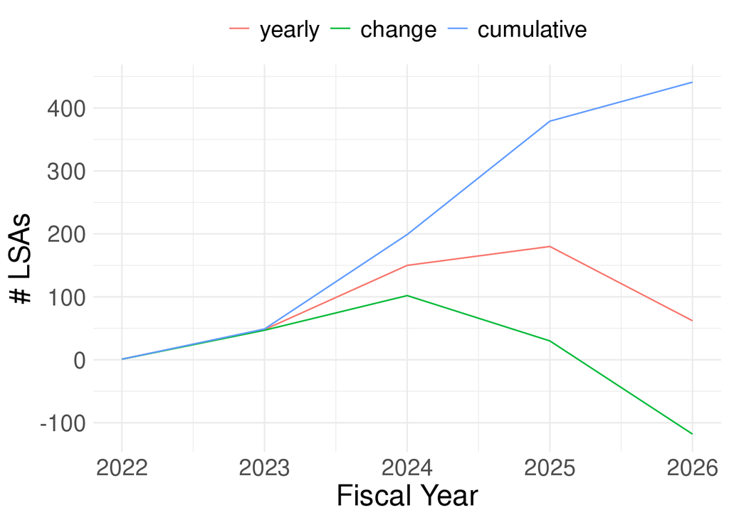

| Fiscal Year | Yearly | Change | (%) | Cumulative |
| --- | --- | --- | --- | --- |
| 2022 | 1 | 1 |  | 1 |
| 2023 | 48 | 47 | +4700% | 49 |
| 2024 | 150 | 102 | +212% | 199 |
| 2025 | 180 | 30 | +20% | 379 |
| 2026 | 62 | -118 | -66% | 441 |

Figure 1: Spending Authorizations by Year

### 1.2 Gov’t Counts

Here we have annual data on the number of local governments submitting spending authorizations:

- The number submitting **yearly** (in a given year).
- The **change** (and **%** change) in the total number of governments submitting over the previous year.
- The total **cumulative** number of local governments that have submitted any spending authorizations since the beginning of the settlement.

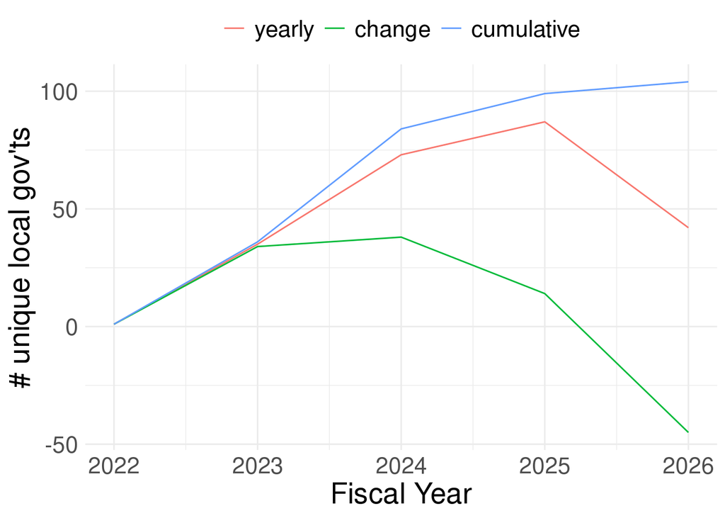

| Fiscal Year | Yearly | Change | (%) | Cumulative |
| --- | --- | --- | --- | --- |
| 2022 | 1 | 1 |  | 1 |
| 2023 | 35 | 34 | +3400% | 36 |
| 2024 | 73 | 38 | +109% | 84 |
| 2025 | 87 | 14 | +19% | 99 |
| 2026 | 42 | -45 | -52% | 104 |

Figure 2: Unique Governments Authorizing by Fiscal Year

### 1.3 Unique Strategy Counts

Here we have annual data on the number of unique strategies authorized:

- The number of unique strategies authorized **yearly** (in a given year).
- The **change** (and **%** change) in the total number of unique strategies funded over the previous year.
- The total **cumulative** number of unique strategies authorized since the beginning of the settlement.

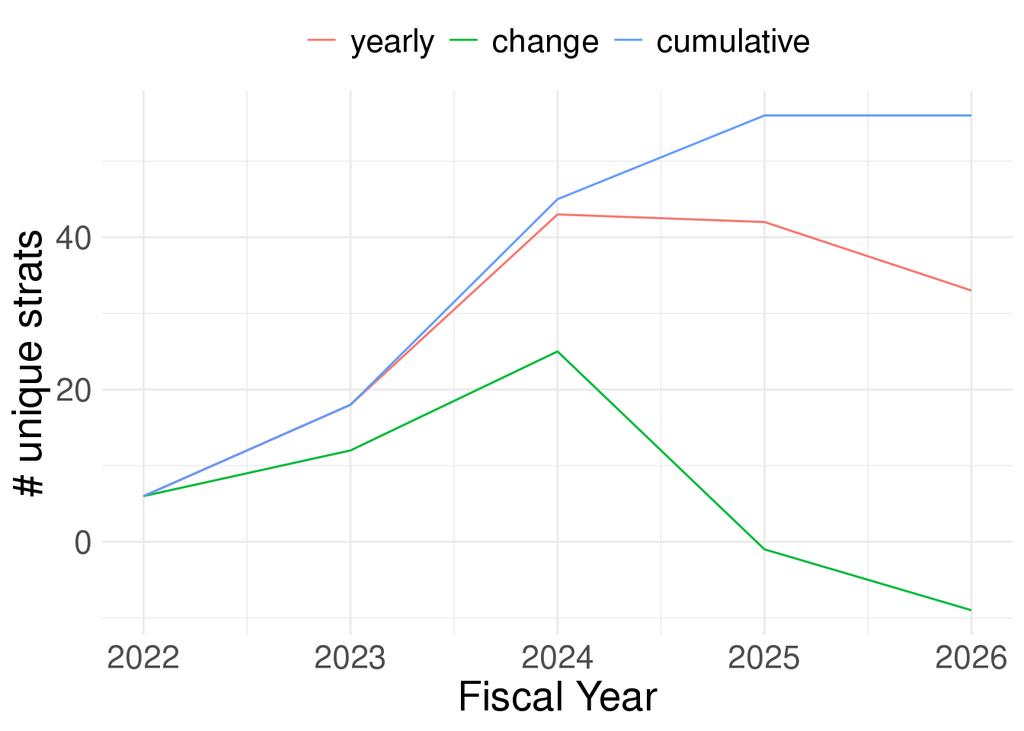

| Fiscal Year | Yearly | Change | (%) | Cumulative |
| --- | --- | --- | --- | --- |
| 2022 | 6 | 6 |  | 6 |
| 2023 | 18 | 12 | +200% | 18 |
| 2024 | 43 | 25 | +139% | 45 |
| 2025 | 42 | -1 | -2% | 56 |
| 2026 | 33 | -9 | -21% | 56 |

Figure 3: Unique Strategies Authorized by Fiscal Year

## 2 Funding

### 2.1 Total Spent

Here we have data on the total amount of settlement funds spent on strategies:

- The total amount spent **yearly**.
- The **change** (and **%** change) in the amount spent from the previous year to the current year.
- The total **cumulative** amount spent since the beginning of the settlement.

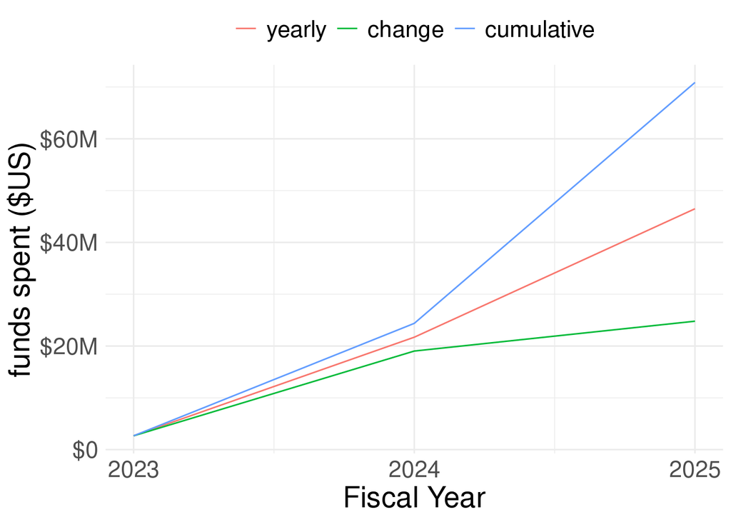

| Fiscal Year | Yearly | Change | (%) | Cumulative |
| --- | --- | --- | --- | --- |
| 2023 | $2.67M | $2.67M |  | $2.67M |
| 2024 | $21.7M | $19M | +712% | $24.4M |
| 2025 | $46.5M | $24.8M | +114% | $70.9M |

Figure 4: Funds Spent by Fiscal Year

### 2.2 Gov’ts Funding

Here we look at the total number of local governments spending settlement funds:

- The total number of governments funding strategies **yearly**.
- The **change** (and **%** change) in the total number of governments funding strategies over the previous year.
- The total **cumulative** number of unique local governments that have funded any strategies since the beginning of the settlemnet.

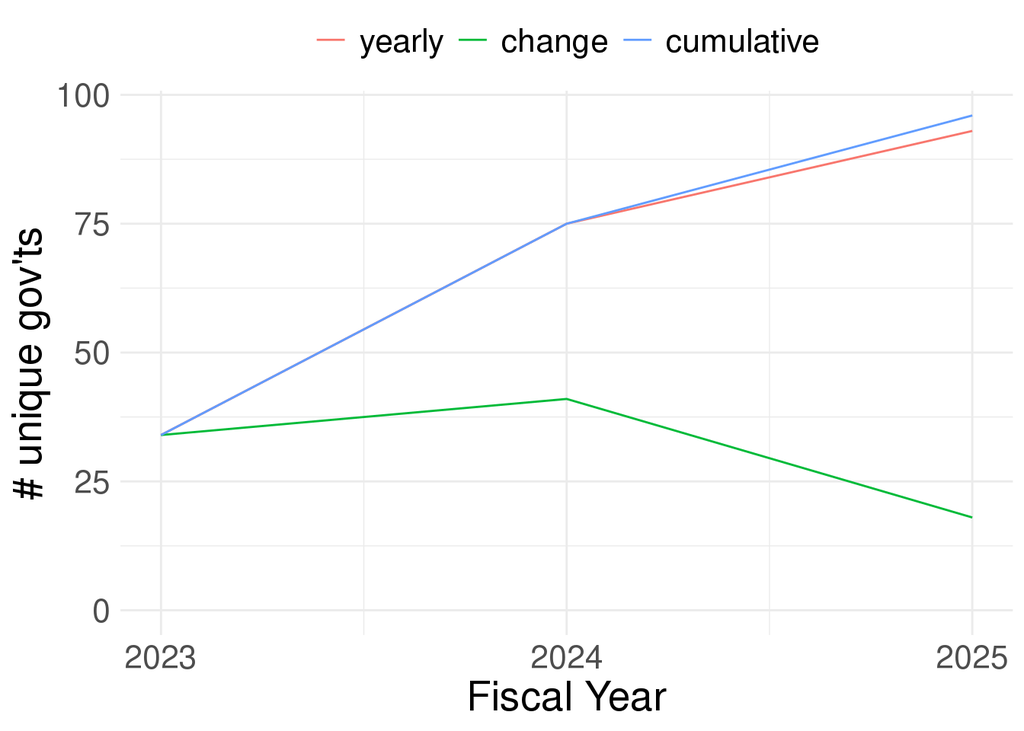

| Fiscal Year | Yearly | Change | (%) | Cumulative |
| --- | --- | --- | --- | --- |
| 2023 | 34 | 34 |  | 34 |
| 2024 | 75 | 41 | +121% | 75 |
| 2025 | 93 | 18 | +24% | 96 |

Figure 5: Unique Gov’ts Funding Strategies by Year

### 2.3 Total Strategies

Here we have data on the total number of strategies funded anually:

- The total number funded **yearly**.
- The **change** (and **%** change) in the number of strategies funded from the previous year.

Note there is no meaningful “cumulative” value; any given government may fund the same program multiple years in a row, complicating this as a measure.

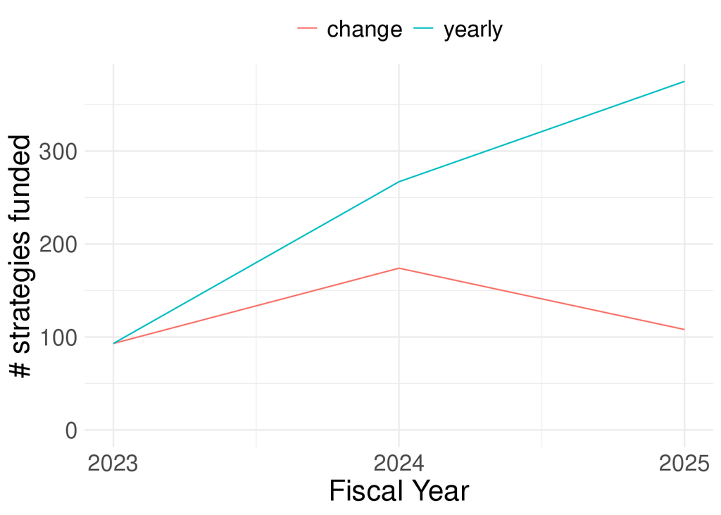

| Fiscal Year | Yearly | Change | (%) |
| --- | --- | --- | --- |
| 2023 | 93 | 93 |  |
| 2024 | 267 | 174 | +187% |
| 2025 | 375 | 108 | +40% |

Figure 6: Total Strategies Funded by Year

### 2.4 Unique Strategies

Here we have data about the number of unique strategies funded anually:

- The total number of unique strategies funded **yearly** (in a given year).
- The **change** (and **%** change) in the number of unique strategies funded over the previous year.
- The **cumulative** number of unique strategies funded since the beginning of the settlement.

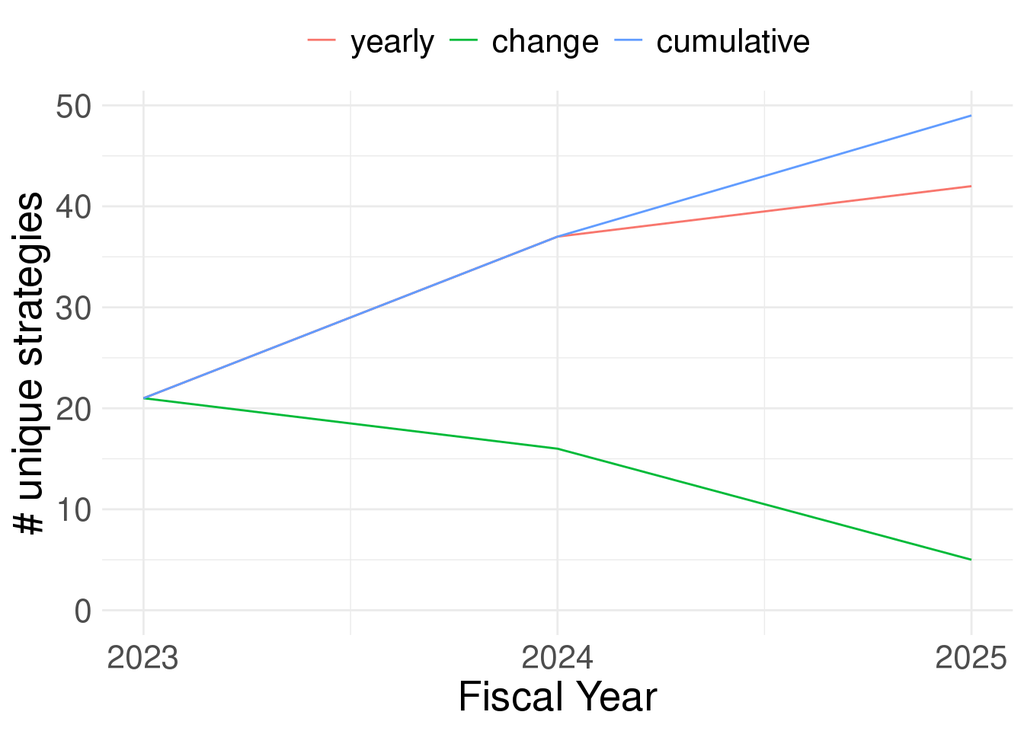

| Fiscal Year | Yearly | Change | (%) | Cumulative |
| --- | --- | --- | --- | --- |
| 2023 | 21 | 21 |  | 21 |
| 2024 | 37 | 16 | +76% | 37 |
| 2025 | 42 | 5 | +14% | 49 |

Figure 7: Unique Strategies Funded by Year

## 3 Implementation Stage

### 3.1 Advancement by Gov’t

Here we have the count of governments who report the given stage as the implementation stage of their *most-advanced* strategy.

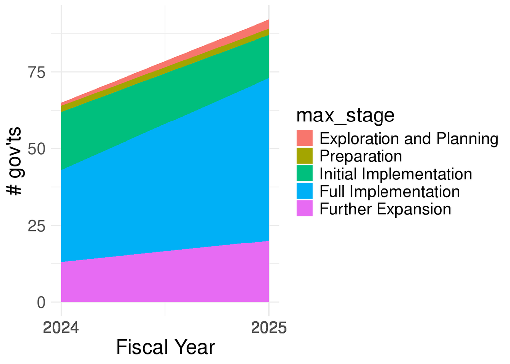

| Fiscal Year | Plan | Prep | Initial | Full | Further |
| --- | --- | --- | --- | --- | --- |
| 2024 | 1 | 2 | 19 | 30 | 13 |
| 2025 | 3 | 2 | 14 | 53 | 20 |

Figure 8: Count of local governments reporting the level of their most-advanced strategy

That same data broken down by local government:

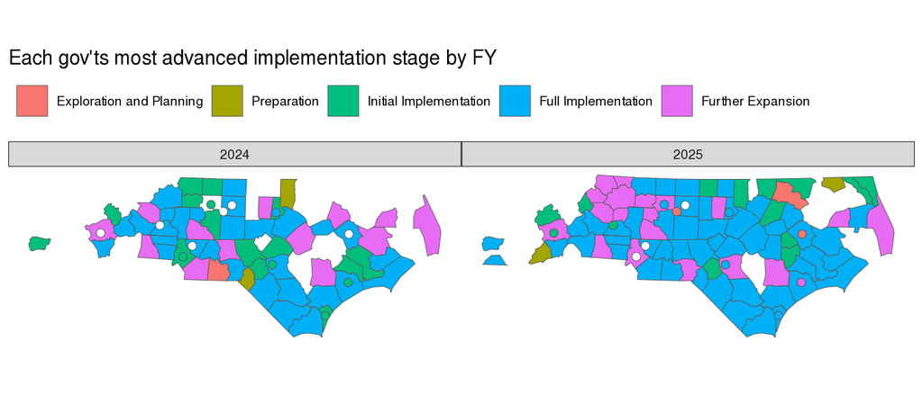

Figure 9: The implementation stage of each local government’s most advanced strategy

### 3.2 Overall Advancement

Here we have the number of strategies reported to be at each implementation stage.

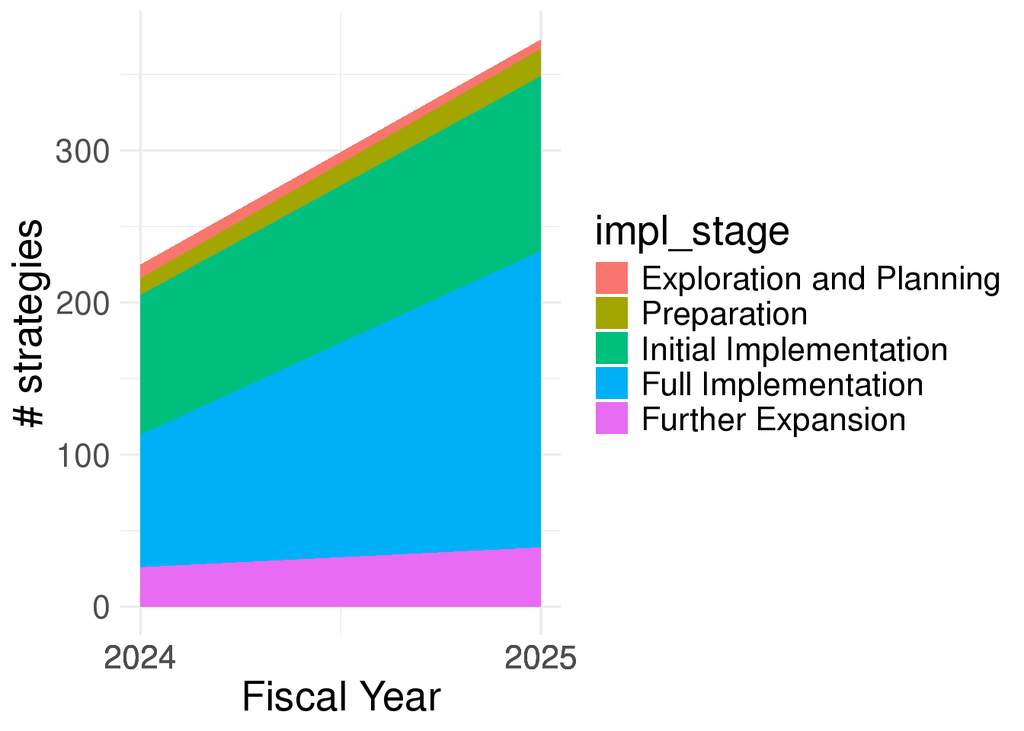

| Fiscal Year | Plan | Prep | Initial | Full | Further |
| --- | --- | --- | --- | --- | --- |
| 2024 | 9 | 11 | 92 | 87 | 26 |
| 2025 | 6 | 18 | 115 | 195 | 39 |

Figure 10: Count of strategies reported at each implementation stage

### 3.3 Advancement by Strategy

Here we have implementation stage broken up by strategy for the most recent fiscal year, 2025.

(To maintain sanity, we consider Exhibit A strategies only.)

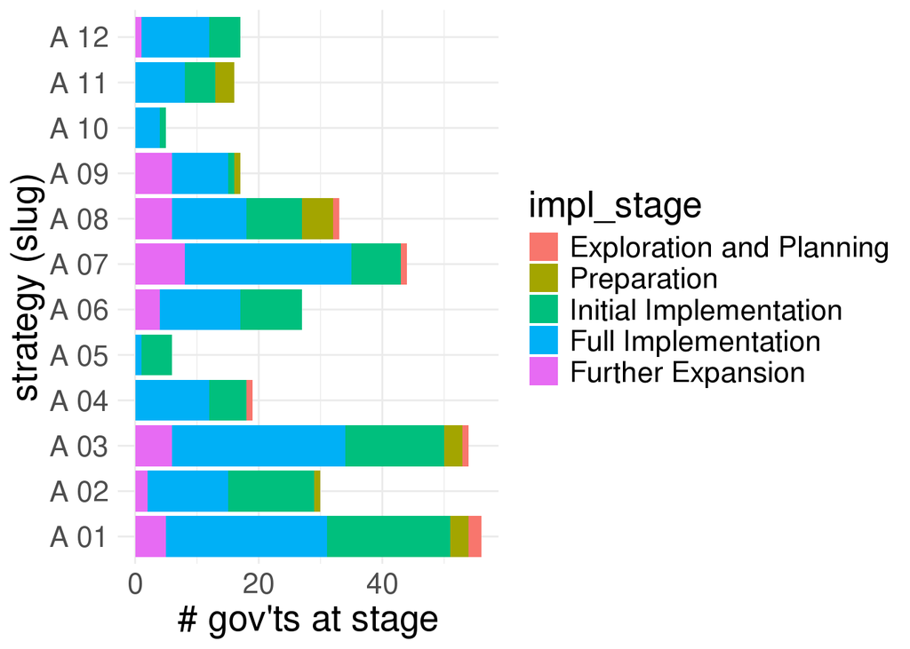

| Strat | Plan | Prep | Initial | Full | Further |
| --- | --- | --- | --- | --- | --- |
| A 01 | 2 | 3 | 20 | 26 | 5 |
| A 02 | 0 | 1 | 14 | 13 | 2 |
| A 03 | 1 | 3 | 16 | 28 | 6 |
| A 04 | 1 | 0 | 6 | 12 | 0 |
| A 05 | 0 | 0 | 5 | 1 | 0 |
| A 06 | 0 | 0 | 10 | 13 | 4 |
| A 07 | 1 | 0 | 8 | 27 | 8 |
| A 08 | 1 | 5 | 9 | 12 | 6 |
| A 09 | 0 | 1 | 1 | 9 | 6 |
| A 10 | 0 | 0 | 1 | 4 | 0 |
| A 11 | 0 | 3 | 5 | 8 | 0 |
| A 12 | 0 | 0 | 5 | 11 | 1 |

Figure 11: Count of implementation stage reported by strategy

That same information, broken up by local government:

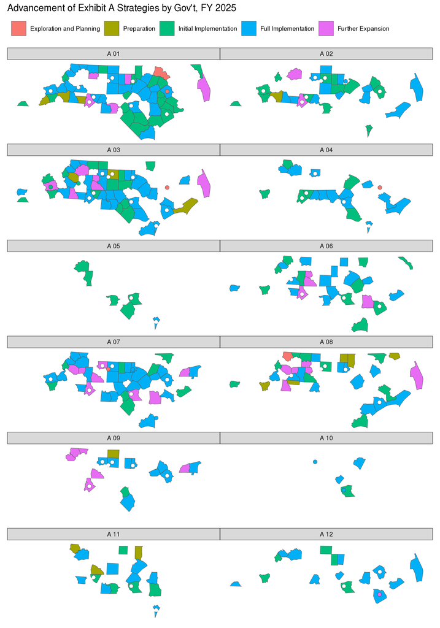

Figure 12: Advancement of Exhibit A strategies by local government